# Final

16 December 2020

#### Instructions

- Answer the following questions, and show all your R code.
- Upload your submission to Canvas in nicely formatted HTML generated from Rstudio.
- Each question is worth 2 points, for 10 points total.

## 1

Define a function `plot_red` as a wrapper function to `plot` that changes the default color to red (`col = "red"`).

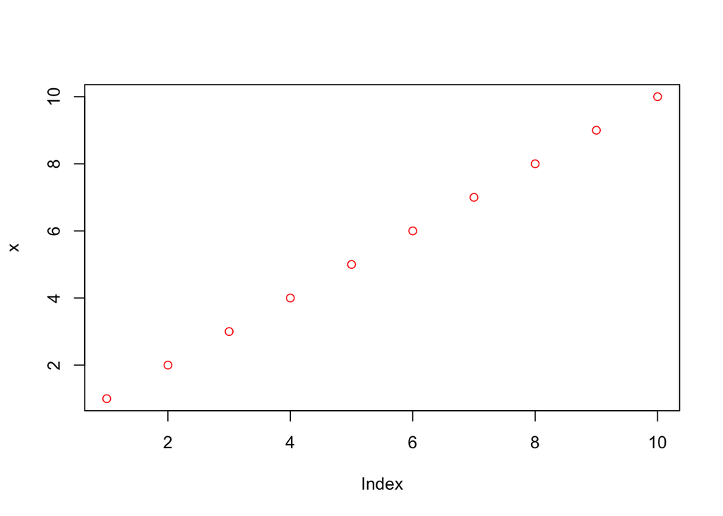

```r
plot_red = function(x) {
  plot(x = x, col = "red")
}
plot_red(1:10)
```

## 2

Model `y` below as a linear function of `x`. Show that the model predicts 19.54463 when x is 20.

```r
x = 1:10
y = x + sin(x)

train = data.frame(x,y)
model = lm(y ~ x, data = train)

test = data.frame(x=20)
pred = predict(model,test)

pred
```

```
##        1
## 19.54463
```

## 3

Read all of these files in and combine them into one single data frame, `d`. If you do it correctly, `d` will have 30 rows. You can do this idiomatically in three lines of code.

```r
file_names = list.files("letters_for_stat128_final", full.names = TRUE)
letters = lapply(file_names, read.csv)
d = do.call(rbind,letters)
d
```

```
##    letter number
## 1       b      1
## 2       b      2
## 3       b      3
## 4       d      1
## 5       d      2
## 6       d      3
## 7       e      1
## 8       e      2
## 9       e      3
## 10      i      1
## 11      i      2
## 12      i      3
## 13      m      1
## 14      m      2
```

[output cut: 16 more lines]

```r
# Cleaning up, leave this as the last line
unlink("letters_for_stat128_final", recursive = TRUE)
```

## 4

Extract the 10 digit phone numbers from the following character vector.

```r
s = c("My number is 593-461-0728"
      , "My address is 123 Fake Street, and my phone number is 578-163-4290, thanks."
      , "Either call 269-501-3748 or email foo@bar.com.")
re = regexec("[0-9]{3}-[0-9]{3}-[0-9]{4}",s)
result = regmatches(s,re)
result
```

```
## [[1]]
## [1] "593-461-0728"
##
## [[2]]
## [1] "578-163-4290"
##
## [[3]]
## [1] "269-501-3748"
```

```r
goal = c("593-461-0728", "578-163-4290", "269-501-3748")
```

## 5

Define a new `print` method for objects of class `final` that accepts any arguments and prints out `We're done!`. Hint: use `cat()`.

```r
s = "This is it?"

class(s) = c("final", class(s))

print.final = function(...) {
  cat("We're done!")
}
print(s)
```

```
## We're done!
```

```r
s
```

```
## We're done!
```

Here’s the behavior you should see in the console after you define your method:

```
> s
We're done!
>
```